# New York Philharmonic

2023-06-22

## Dataset usato

New York Philharmonic, pubblicato su https://github.com/nyphilarchive/PerformanceHistory e disponibile in XML o JSON (che ho usato). Orchestra americana, ancora attiva, fondata nel 1842.

```javascript
  "programs": [
    {
      "id": "38e072a7-8fc9-4f9a-8eac-3957905c0002", // GUID
      "programID": "3853", // NYP Local ID
      "orchestra": "New York Philharmonic",
      "season": "1842-43",
          "concerts": [ { ... }, /* A program can have multiple concerts */ ],
      "works": [ {
          "composerName": "Weber,  Carl  Maria Von",
          "workTitle": "OBERON",
          "conductorName": "Timm, Henry C.",
        "soloists": [ ... ] }, /* a program will usually have multiple works */ { ... }, ] },
    /* more programs */
  ]
```

## Dataset usato

11 orchestre nel database, più eventi senza orchestra. La stragrande maggioranza delle performance sono della New York Philharmonic.

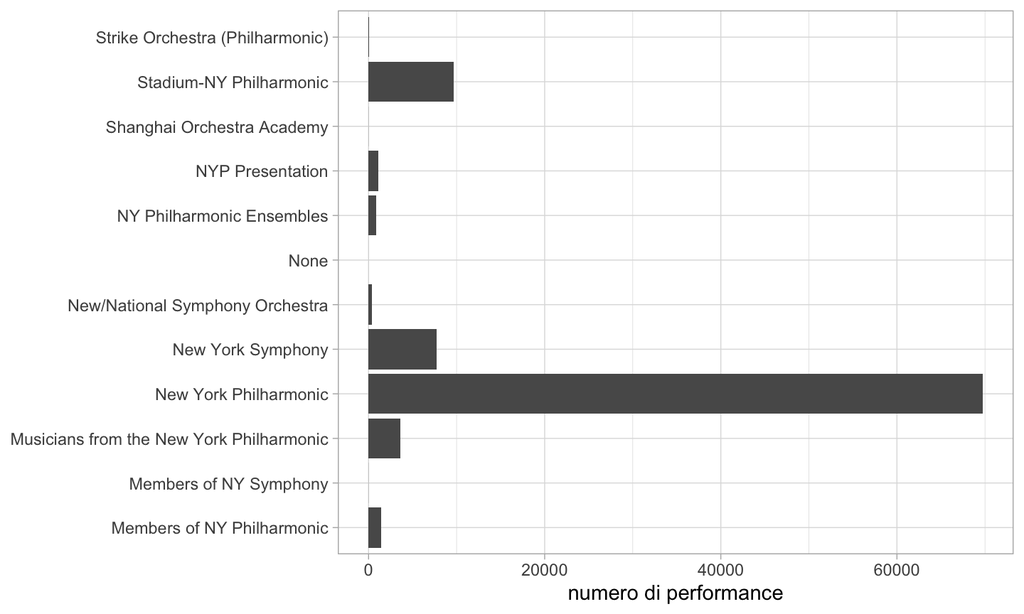

## Dataset usato

La New York Philharmonic è quella più presente nel corso della storia.

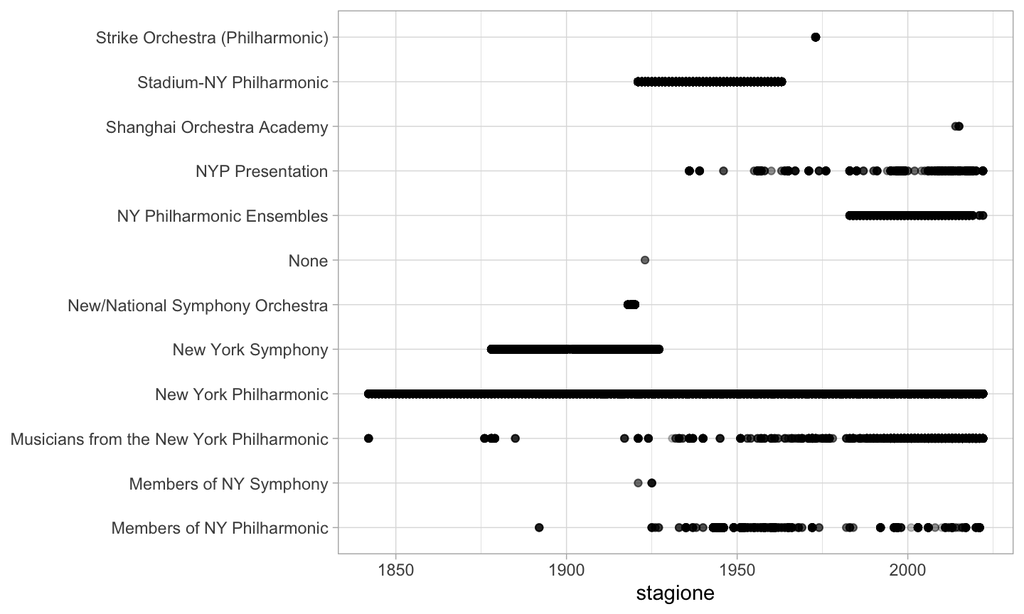

## Compositori nel tempo

Come evolve negli anni (nel lungo periodo) il repertorio dell’orchestra? Ci sono compositori per cui cresce o diminuisce il numero di rappresentazioni?

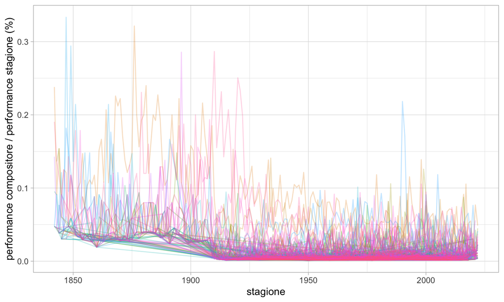

## Compositori nel tempo

Componenti quadratiche positive (Dvorak, Strauss) e negative (Ravel, Prokofiev).

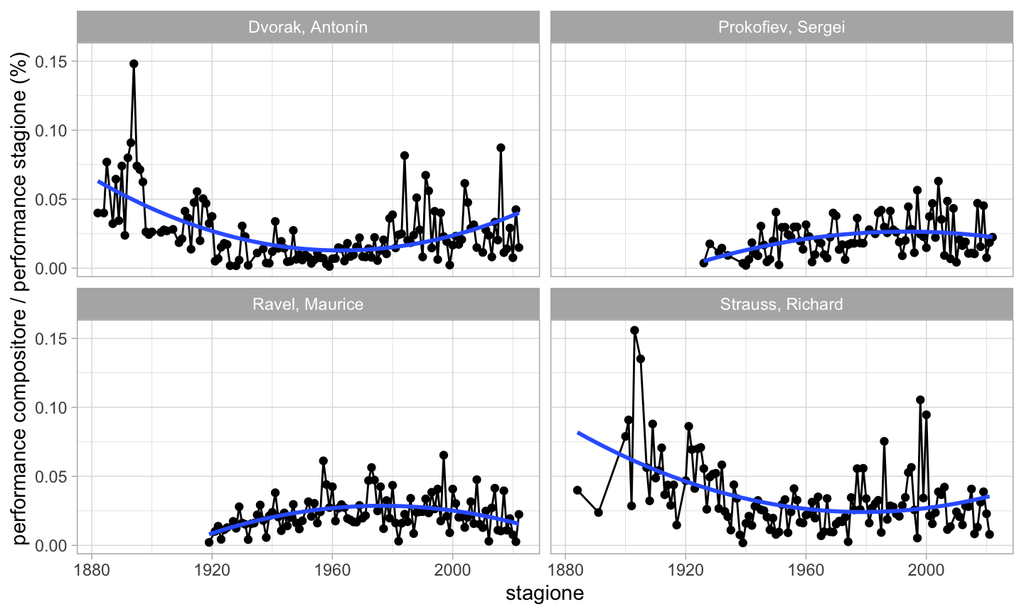

## Compositori nel tempo

Alcuni modelli che hanno un buon fit.

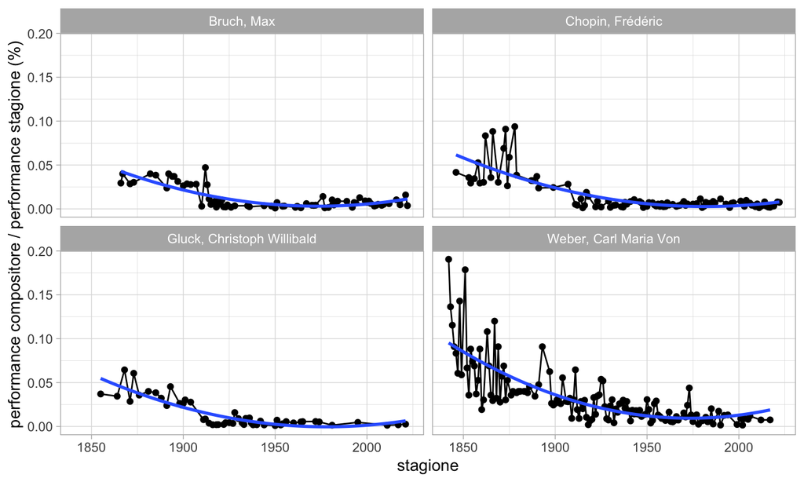

## Compositori nel tempo

Guardo ai compositori che hanno residui più alti di 0.1 (nel plot la percentuale).

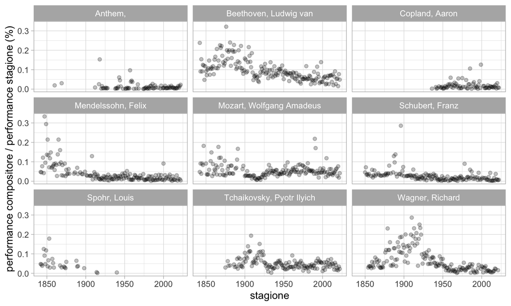

## Compositori nel tempo

Le stagioni prima del 1909 sono molto più “eque” nella divisione delle performance fra diversi compositori

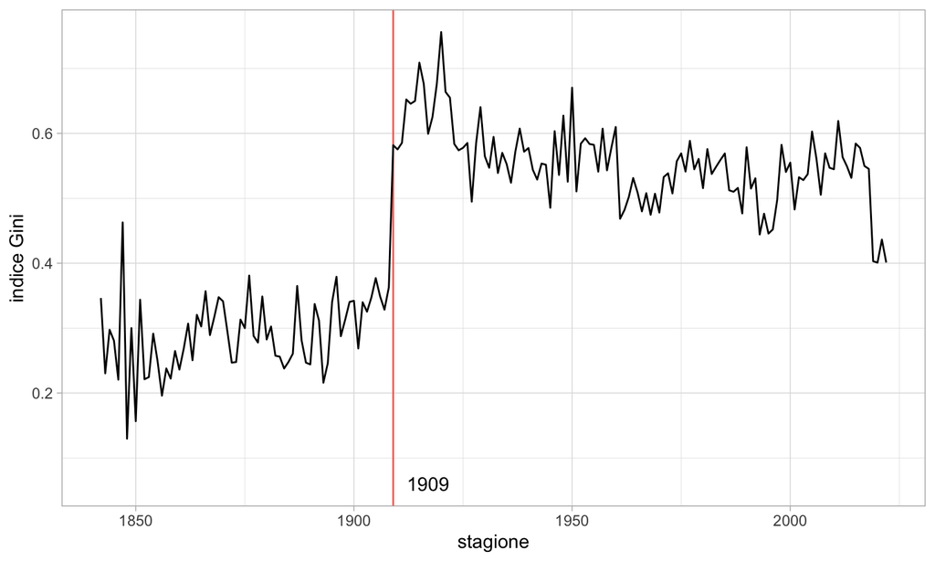

## Compositori nel tempo

Questo nonostante aumenti il numero di compositori.

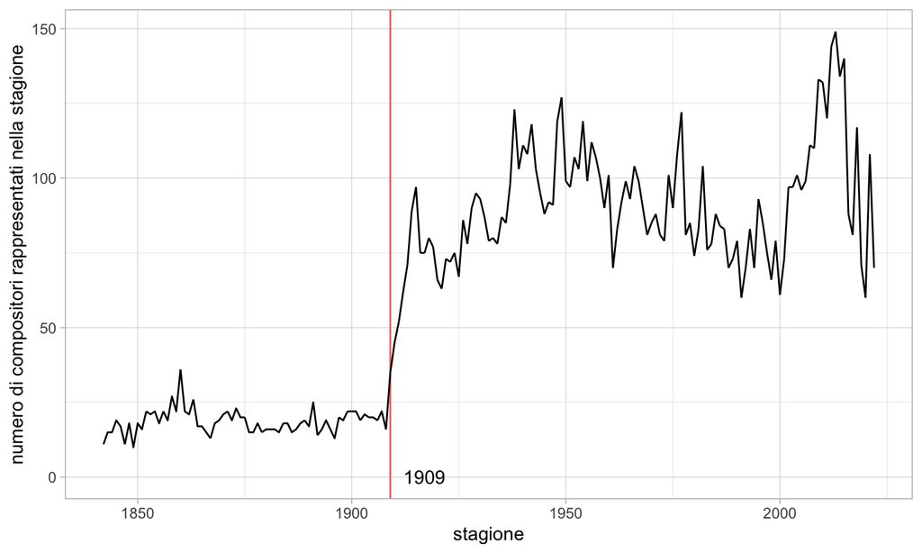

## Compositori nel tempo

Mediana percentuali.

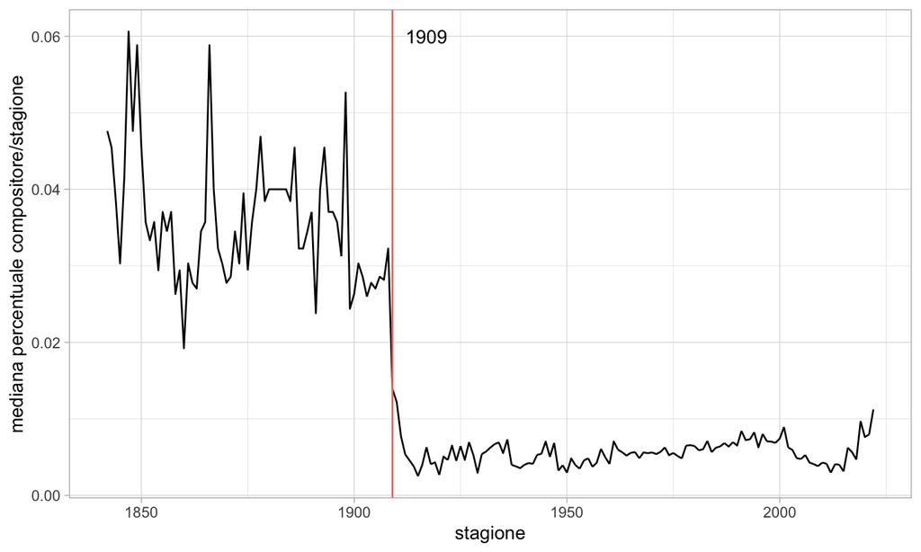

## Compositori nel tempo

Compositori rappresentati prima della stagione 1909-1910 per almeno dieci stagioni.

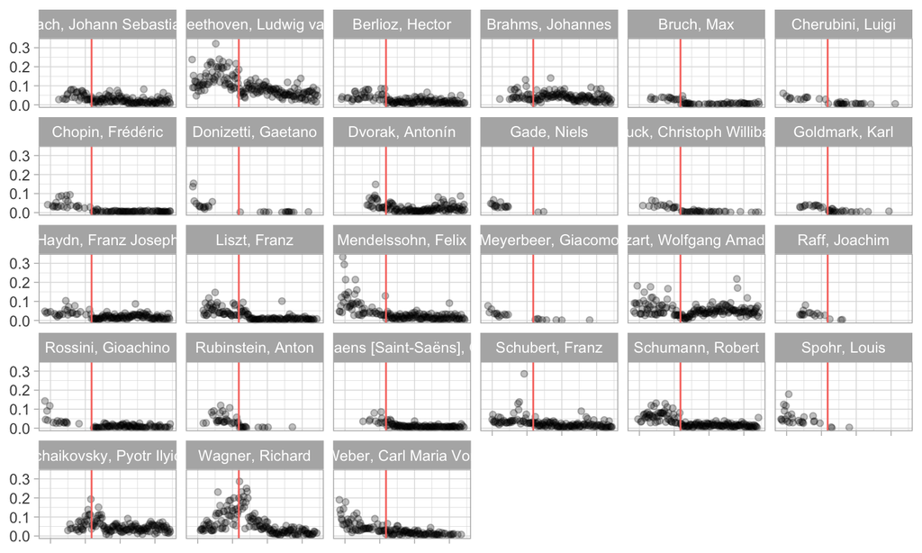

## Conduttori nel tempo

È possibile individuare dei trend nei repertori dei conduttori?

## Conduttori nel tempo

Leonard Bernstein - alcuni modelli che fittano bene.

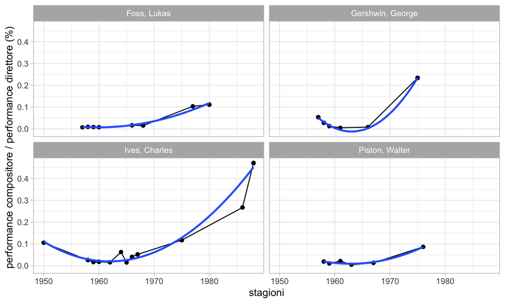

## Conduttori nel tempo

Leonard Bernstein - alcuni modelli che non fittano bene.

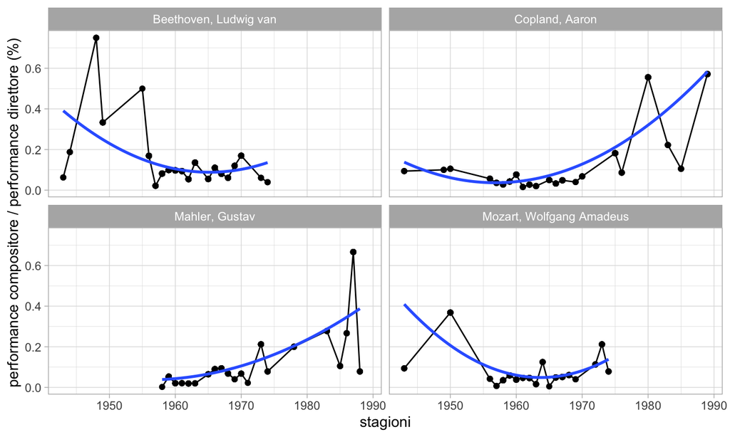